# Practical Machine Learning - Project

Oscar Peña del Rio

27/12/2015

First, we load all the libraries we will be using within our analysis, and load the data itself (we suppose the data is present in the same folder as the R script).

```r
library(caret)
library(randomForest)
library(rattle)
```

```r
library(rpart.plot)
library(RColorBrewer)

training_data <- read.csv('pml-training.csv')
testing_data <- read.csv('pml-testing.csv')
```

Print how many observations and variables we have in each dataset.

```r
dim(training_data)
```

```
## [1] 19622   160
```

```r
dim(testing_data)
```

```
## [1]  20 160
```

```r
training_data <- training_data[, colSums(is.na(training_data)) == 0]
testing_data <- testing_data[, colSums(is.na(testing_data)) == 0]
```

We still have some columns we are not interested in, so we are going to remove some of them manually from the *testing_data* set, and the drop all the columns from *training_data* which are not present in *testing_data* (they are NOT sensor related). We will save the *classe* column and append it afterwards to the *training_data* set.

```r
testing_data <- subset(testing_data, select=-c(
  X, raw_timestamp_part_1, raw_timestamp_part_2,
  cvtd_timestamp, new_window, num_window, problem_id
))

dim(testing_data)
```

```
## [1] 20 53
```

```r
col_names_to_keep <- colnames(testing_data)
classe <- training_data$classe

training_data <- training_data[, (colnames(training_data) %in% col_names_to_keep)]
training_data$classe <- classe
dim(training_data)
```

```
## [1] 19622    54
```

Let’s begin our prediction!

First, we create a partition on our *training_data* for cross validation, 70% will form the *train_data* set and the remaining 30% the *test_data* set.

```r
# set seed to today's date
set.seed(20151227)

for_training <- createDataPartition(training_data$classe, p=0.7, list=FALSE)

train_data <- training_data[for_training,]
test_data <- training_data[-for_training,]
```

```r
RF_model <- randomForest(
  train_data$classe ~ .,
  data=train_data,
  ntree=250
)

RF_model
```

```
##
## Call:
##  randomForest(formula = train_data$classe ~ ., data = train_data,      ntree = 250)
##                Type of random forest: classification
##                      Number of trees: 250
## No. of variables tried at each split: 7
##
##         OOB estimate of  error rate: 0.5%
## Confusion matrix:
##      A    B    C    D    E class.error
## A 3902    3    0    1    0 0.001024066
## B    9 2641    8    0    0 0.006395786
## C    0    9 2385    2    0 0.004590985
## D    0    0   27 2223    2 0.012877442
## E    0    0    1    6 2518 0.002772277
```

Now, we build our prediction tool, and check it against the *test_data* set.

```r
RF_prediction <- predict(RF_model, test_data)

confusion_matrix <- confusionMatrix(test_data$classe, RF_prediction)

model_accuracy <- postResample(RF_prediction, test_data$classe)
model_error <- 1 - as.numeric(confusion_matrix$overall[1])
```

Finally, we print all the results:

```r
confusion_matrix
```

```
## Confusion Matrix and Statistics
##
##           Reference
## Prediction    A    B    C    D    E
##          A 1673    1    0    0    0
##          B    8 1130    1    0    0
##          C    0    7 1019    0    0
##          D    0    0   16  948    0
##          E    0    0    0    3 1079
##
## Overall Statistics
##
##                Accuracy : 0.9939
##                  95% CI : (0.9915, 0.9957)
##     No Information Rate : 0.2856
##     P-Value [Acc > NIR] : < 2.2e-16
##
##                   Kappa : 0.9923
##  Mcnemar's Test P-Value : NA
##
## Statistics by Class:
##
##                      Class: A Class: B Class: C Class: D Class: E
## Sensitivity            0.9952   0.9930   0.9836   0.9968   1.0000
## Specificity            0.9998   0.9981   0.9986   0.9968   0.9994
## Pos Pred Value         0.9994   0.9921   0.9932   0.9834   0.9972
## Neg Pred Value         0.9981   0.9983   0.9965   0.9994   1.0000
## Prevalence             0.2856   0.1934   0.1760   0.1616   0.1833
## Detection Rate         0.2843   0.1920   0.1732   0.1611   0.1833
## Detection Prevalence   0.2845   0.1935   0.1743   0.1638   0.1839
## Balanced Accuracy      0.9975   0.9955   0.9911   0.9968   0.9997
```

```r
model_accuracy
```

```
##  Accuracy     Kappa
## 0.9938828 0.9922611
```

```r
model_error
```

```
## [1] 0.006117247
```

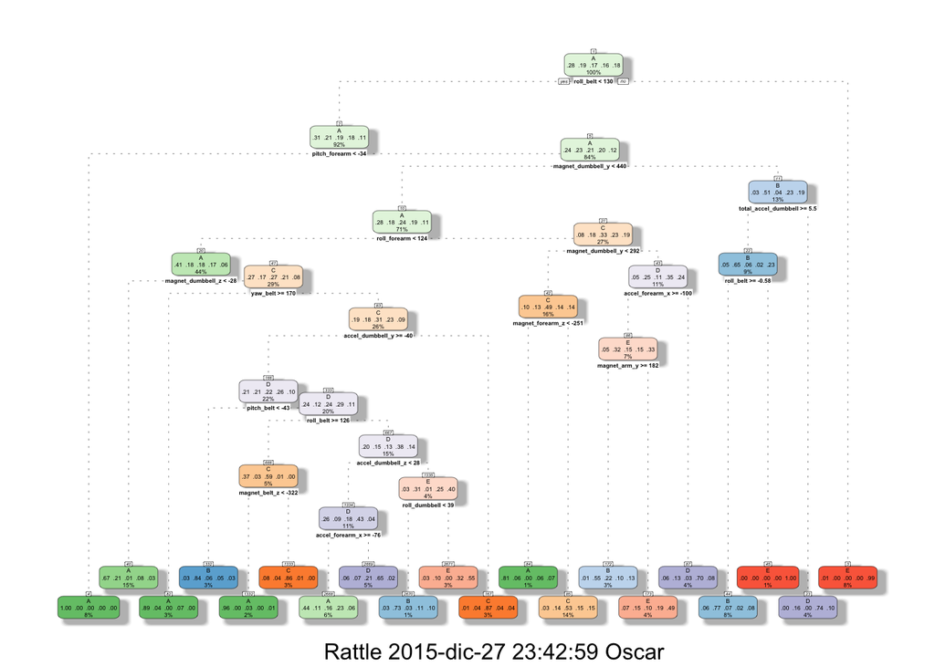

```r
decision_tree <- rpart(
  train_data$classe ~ .,
  data=train_data,
  method='class'
)

fancyRpartPlot(decision_tree)
```

## Conclusions

We have an accuracy of 99.39%, with an error rate of 0.61%. They are quite good results for a *quick* analysis. So we launch it against the initial *testing_data* set, in order to predict their outcome values.

```r
prediction <- predict(RF_model, testing_data)

prediction
```

```
##  1  2  3  4  5  6  7  8  9 10 11 12 13 14 15 16 17 18 19 20
##  B  A  B  A  A  E  D  B  A  A  B  C  B  A  E  E  A  B  B  B
## Levels: A B C D E
```